# Workflow for plotting ring-necked duck migration patterns in North America

## 4. Join the species and ecoregions data to calculate occurrences

```python
# Join the geodataframes
join_gdf = (
    eco_gdf
    # Match the CRS of the GBIF data and the ecoregions
    .to_crs(gbif_gdf.crs)
    # Find ecoregion for each observation
    .sjoin(
        gbif_gdf,
        how='inner',
        predicate='contains')
    [['OBJECTID','month']]
    .rename(columns = {'OBJECTID': 'ecoregion'})
)
join_gdf
```

|  | ecoregion | month |
| --- | --- | --- |
| 9 | 10.0 | 9.0 |
| 9 | 10.0 | 5.0 |
| 9 | 10.0 | 6.0 |
| 9 | 10.0 | 5.0 |
| 9 | 10.0 | 5.0 |
| ... | ... | ... |
| 839 | 845.0 | 6.0 |
| 839 | 845.0 | 8.0 |
| 839 | 845.0 | 6.0 |
| 839 | 845.0 | 8.0 |
| 839 | 845.0 | 6.0 |

373869 rows × 2 columns

## 5. Normalize the data by month and ecoregion

```python
# Set up new df
occ_df = (
    join_gdf
    .groupby(['ecoregion', 'month'])
    # Count the number of occurrences
    .agg(occurrences=('ecoregion', 'count'))
)

# Get rid of rare observations (possible misidentification?)
occ_df = occ_df[occ_df.occurrences > 1]

# Take the mean by ecoregion
mean_occ_by_eco = (
    occ_df
    .groupby('ecoregion')
    .mean()
)
# Take the mean by month
mean_occ_by_month = (
    occ_df
    .groupby('month')
    .mean()
)

# Helpful to visualize the difference in data at this stage
print("occurrence_df:\n" , occ_df)
```

```
occurrence_df:
                  occurrences
ecoregion month
10.0      5.0             29
          6.0             26
          7.0             23
          9.0              2
11.0      1.0             10
...                      ...
845.0     5.0             10
          6.0              4
          8.0              2
          10.0             3
          12.0             2

[1251 rows x 1 columns]
```

```python
# Compare to grouped by month
print("mean_occ_by_month:\n:", mean_occ_by_month)
```

```
mean_occ_by_month:
:        occurrences
month
1.0     403.361538
2.0     384.120000
3.0     564.487603
4.0     594.870000
5.0     220.504950
6.0     105.080460
7.0      51.880000
8.0      52.171429
9.0      84.816092
10.0    194.675926
11.0    299.512195
12.0    333.370968
```

```python
# And compared to occurrence grouping
print("mean_occ_by_eco:\n", mean_occ_by_eco)
```

```
mean_occ_by_eco:
            occurrences
ecoregion
10.0         20.000000
11.0         10.666667
13.0         42.125000
16.0          9.250000
17.0        324.333333
...                ...
833.0        15.833333
838.0        43.916667
839.0       343.416667
844.0         9.500000
845.0         3.875000

[173 rows x 1 columns]
```

```python
# Normalize each month and ecoregion for sampling effort
occ_df['norm_occurrences'] = (
    occ_df
    / mean_occ_by_month
    / mean_occ_by_eco
)
occ_df
```

| ecoregion | month | occurrences | norm_occurrences |
| --- | --- | --- | --- |
| 10.0 | 5.0 | 29 | 0.006576 |
|  | 6.0 | 26 | 0.012371 |
|  | 7.0 | 23 | 0.022167 |
|  | 9.0 | 2 | 0.001179 |
| 11.0 | 1.0 | 10 | 0.002324 |
| ... | ... | ... | ... |
| 845.0 | 5.0 | 10 | 0.011703 |
|  | 6.0 | 4 | 0.009824 |
|  | 8.0 | 2 | 0.009893 |
|  | 10.0 | 3 | 0.003977 |
|  | 12.0 | 2 | 0.001548 |

1251 rows × 2 columns

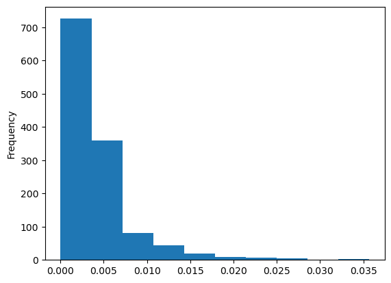

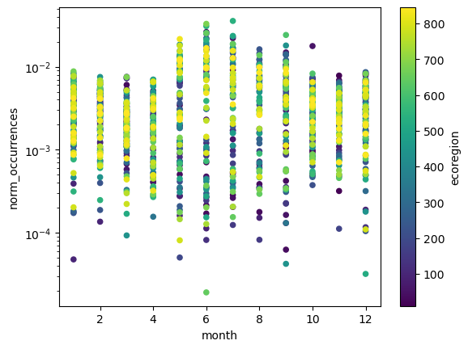

```python
# Plot normalized data to confirm expected range

# Plot (hist)
occ_df.norm_occurrences.plot.hist()

# Plot (scatter)
occ_df.reset_index().plot.scatter(
    x = 'month',
    y = 'norm_occurrences',
    c = 'ecoregion',
    logy = True
)
```

## 6. Join occurrences and ecoregions data for final plot

```python
# Simplify the geometry to speed up processing
eco_gdf.geometry = eco_gdf.simplify(
    .1, preserve_topology = False)

# Change the CRS to Mercator for mapping
eco_gdf = eco_gdf.to_crs(ccrs.Mercator())

# Check that the plot runs in a reasonable amount of time
eco_gdf.hvplot(geo=True, crs=ccrs.Mercator())
```

```python
# Check column names
occ_df.head()
```

| ecoregion | month | occurrences | norm_occurrences |
| --- | --- | --- | --- |
| 10.0 | 5.0 | 29 | 0.006576 |
|  | 6.0 | 26 | 0.012371 |
|  | 7.0 | 23 | 0.022167 |
|  | 9.0 | 2 | 0.001179 |
| 11.0 | 1.0 | 10 | 0.002324 |

```python
# Check column names
eco_gdf.head()
```

|  | OBJECTID | ECO_NAME | BIOME_NUM | BIOME_NAME | REALM | ECO_BIOME_ | NNH | ECO_ID | SHAPE_LENG | SHAPE_AREA | NNH_NAME | COLOR | COLOR_BIO | COLOR_NNH | LICENSE | geometry |
| --- | --- | --- | --- | --- | --- | --- | --- | --- | --- | --- | --- | --- | --- | --- | --- | --- |
| 0 | 1.0 | Adelie Land tundra | 11.0 | Tundra | Antarctica | AN11 | 1 | 117 | 9.749780 | 0.038948 | Half Protected | #63CFAB | #9ED7C2 | #257339 | CC-BY 4.0 | MULTIPOLYGON EMPTY |
| 1 | 2.0 | Admiralty Islands lowland rain forests | 1.0 | Tropical & Subtropical Moist Broadleaf Forests | Australasia | AU01 | 2 | 135 | 4.800349 | 0.170599 | Nature Could Reach Half Protected | #70A800 | #38A700 | #7BC141 | CC-BY 4.0 | POLYGON ((16411777.375 -229101.376, 16384825.7... |
| 2 | 3.0 | Aegean and Western Turkey sclerophyllous and m... | 12.0 | Mediterranean Forests, Woodlands & Scrub | Palearctic | PA12 | 4 | 785 | 162.523044 | 13.844952 | Nature Imperiled | #FF7F7C | #FE0000 | #EE1E23 | CC-BY 4.0 | MULTIPOLYGON (((3391149.749 4336064.109, 33846... |
| 3 | 4.0 | Afghan Mountains semi-desert | 13.0 | Deserts & Xeric Shrublands | Palearctic | PA13 | 4 | 807 | 15.084037 | 1.355536 | Nature Imperiled | #FA774D | #CC6767 | #EE1E23 | CC-BY 4.0 | MULTIPOLYGON (((7369001.698 4093509.259, 73168... |
| 4 | 5.0 | Ahklun and Kilbuck Upland Tundra | 11.0 | Tundra | Nearctic | NE11 | 1 | 404 | 22.590087 | 8.196573 | Half Protected | #4C82B6 | #9ED7C2 | #257339 | CC-BY 4.0 | MULTIPOLYGON (((-17930832.005 8046779.358, -17... |

```python
# Line up column names
if 'OBJECTID' in eco_gdf.columns:
    eco_gdf = eco_gdf.rename(columns= {"OBJECTID": "ecoregion"})
    # Set index to ecoregion
    eco_gdf = eco_gdf.set_index('ecoregion')

# Check new column names
eco_gdf.head()
```

| ecoregion | ECO_NAME | BIOME_NUM | BIOME_NAME | REALM | ECO_BIOME_ | NNH | ECO_ID | SHAPE_LENG | SHAPE_AREA | NNH_NAME | COLOR | COLOR_BIO | COLOR_NNH | LICENSE | geometry |
| --- | --- | --- | --- | --- | --- | --- | --- | --- | --- | --- | --- | --- | --- | --- | --- |
| 1.0 | Adelie Land tundra | 11.0 | Tundra | Antarctica | AN11 | 1 | 117 | 9.749780 | 0.038948 | Half Protected | #63CFAB | #9ED7C2 | #257339 | CC-BY 4.0 | MULTIPOLYGON EMPTY |
| 2.0 | Admiralty Islands lowland rain forests | 1.0 | Tropical & Subtropical Moist Broadleaf Forests | Australasia | AU01 | 2 | 135 | 4.800349 | 0.170599 | Nature Could Reach Half Protected | #70A800 | #38A700 | #7BC141 | CC-BY 4.0 | POLYGON ((16411777.375 -229101.376, 16384825.7... |
| 3.0 | Aegean and Western Turkey sclerophyllous and m... | 12.0 | Mediterranean Forests, Woodlands & Scrub | Palearctic | PA12 | 4 | 785 | 162.523044 | 13.844952 | Nature Imperiled | #FF7F7C | #FE0000 | #EE1E23 | CC-BY 4.0 | MULTIPOLYGON (((3391149.749 4336064.109, 33846... |
| 4.0 | Afghan Mountains semi-desert | 13.0 | Deserts & Xeric Shrublands | Palearctic | PA13 | 4 | 807 | 15.084037 | 1.355536 | Nature Imperiled | #FA774D | #CC6767 | #EE1E23 | CC-BY 4.0 | MULTIPOLYGON (((7369001.698 4093509.259, 73168... |
| 5.0 | Ahklun and Kilbuck Upland Tundra | 11.0 | Tundra | Nearctic | NE11 | 1 | 404 | 22.590087 | 8.196573 | Half Protected | #4C82B6 | #9ED7C2 | #257339 | CC-BY 4.0 | MULTIPOLYGON (((-17930832.005 8046779.358, -17... |

```python
# Join the occurrences with the plotting GeoDataFrame
occ_gdf = eco_gdf.join(occ_df)

# Check new column names and grouping
occ_gdf.head()
```

| ecoregion | month | ECO_NAME | BIOME_NUM | BIOME_NAME | REALM | ECO_BIOME_ | NNH | ECO_ID | SHAPE_LENG | SHAPE_AREA | NNH_NAME | COLOR | COLOR_BIO | COLOR_NNH | LICENSE | geometry | occurrences | norm_occurrences |
| --- | --- | --- | --- | --- | --- | --- | --- | --- | --- | --- | --- | --- | --- | --- | --- | --- | --- | --- |
| 10.0 | 5.0 | Alaska-St. Elias Range tundra | 11.0 | Tundra | Nearctic | NE11 | 2 | 405 | 98.400727 | 28.388010 | Nature Could Reach Half Protected | #61D2F2 | #9ED7C2 | #7BC141 | CC-BY 4.0 | MULTIPOLYGON (((-16886232.729 9049093.235, -16... | 29 | 0.006576 |
|  | 6.0 | Alaska-St. Elias Range tundra | 11.0 | Tundra | Nearctic | NE11 | 2 | 405 | 98.400727 | 28.388010 | Nature Could Reach Half Protected | #61D2F2 | #9ED7C2 | #7BC141 | CC-BY 4.0 | MULTIPOLYGON (((-16886232.729 9049093.235, -16... | 26 | 0.012371 |
|  | 7.0 | Alaska-St. Elias Range tundra | 11.0 | Tundra | Nearctic | NE11 | 2 | 405 | 98.400727 | 28.388010 | Nature Could Reach Half Protected | #61D2F2 | #9ED7C2 | #7BC141 | CC-BY 4.0 | MULTIPOLYGON (((-16886232.729 9049093.235, -16... | 23 | 0.022167 |
|  | 9.0 | Alaska-St. Elias Range tundra | 11.0 | Tundra | Nearctic | NE11 | 2 | 405 | 98.400727 | 28.388010 | Nature Could Reach Half Protected | #61D2F2 | #9ED7C2 | #7BC141 | CC-BY 4.0 | MULTIPOLYGON (((-16886232.729 9049093.235, -16... | 2 | 0.001179 |
| 11.0 | 1.0 | Alaska Peninsula montane taiga | 6.0 | Boreal Forests/Taiga | Nearctic | NE06 | 1 | 369 | 96.534475 | 7.247315 | Half Protected | #E2C7FA | #7AB6F5 | #257339 | CC-BY 4.0 | MULTIPOLYGON (((-17060923.633 7930073.99, -170... | 10 | 0.002324 |

## 7. Filter out empty geometries

> Some ecoregions have an empty geometry value which interferes with the plotting below. To avoid this happening, we can pull out all of the ecoregions still in the joined dataset that do not have sufficient geometries, but this does remove the occurrence data entirely for that ecoregion which is not ideal.

```python
# Create a new gdf filtering for empty geometry
filter_gdf = occ_gdf[occ_gdf['geometry'].is_empty]

filter_gdf
```

| ecoregion | month | ECO_NAME | BIOME_NUM | BIOME_NAME | REALM | ECO_BIOME_ | NNH | ECO_ID | SHAPE_LENG | SHAPE_AREA | NNH_NAME | COLOR | COLOR_BIO | COLOR_NNH | LICENSE | geometry | occurrences | norm_occurrences |
| --- | --- | --- | --- | --- | --- | --- | --- | --- | --- | --- | --- | --- | --- | --- | --- | --- | --- | --- |
| 72.0 | 1.0 | Bermuda subtropical conifer forests | 3.0 | Tropical & Subtropical Coniferous Forests | Nearctic | NE03 | 4 | 325 | 0.746025 | 0.003771 | Nature Imperiled | #62A67D | #88CE66 | #EE1E23 | CC-BY 4.0 | MULTIPOLYGON EMPTY | 6 | 0.003542 |
|  | 2.0 | Bermuda subtropical conifer forests | 3.0 | Tropical & Subtropical Coniferous Forests | Nearctic | NE03 | 4 | 325 | 0.746025 | 0.003771 | Nature Imperiled | #62A67D | #88CE66 | #EE1E23 | CC-BY 4.0 | MULTIPOLYGON EMPTY | 5 | 0.003099 |
|  | 9.0 | Bermuda subtropical conifer forests | 3.0 | Tropical & Subtropical Coniferous Forests | Nearctic | NE03 | 4 | 325 | 0.746025 | 0.003771 | Nature Imperiled | #62A67D | #88CE66 | #EE1E23 | CC-BY 4.0 | MULTIPOLYGON EMPTY | 5 | 0.014036 |
|  | 11.0 | Bermuda subtropical conifer forests | 3.0 | Tropical & Subtropical Coniferous Forests | Nearctic | NE03 | 4 | 325 | 0.746025 | 0.003771 | Nature Imperiled | #62A67D | #88CE66 | #EE1E23 | CC-BY 4.0 | MULTIPOLYGON EMPTY | 3 | 0.002385 |
|  | 12.0 | Bermuda subtropical conifer forests | 3.0 | Tropical & Subtropical Coniferous Forests | Nearctic | NE03 | 4 | 325 | 0.746025 | 0.003771 | Nature Imperiled | #62A67D | #88CE66 | #EE1E23 | CC-BY 4.0 | MULTIPOLYGON EMPTY | 2 | 0.001428 |
| 665.0 | 2.0 | Southeast US mixed woodlands and savannas | 8.0 | Temperate Grasslands, Savannas & Shrublands | Nearctic | NE08 | 4 | 400 | 0.884987 | 0.002535 | Nature Imperiled | #E8FC5F | #FEFF73 | #EE1E23 | CC-BY 4.0 | POLYGON EMPTY | 2 | 0.002603 |
|  | 3.0 | Southeast US mixed woodlands and savannas | 8.0 | Temperate Grasslands, Savannas & Shrublands | Nearctic | NE08 | 4 | 400 | 0.884987 | 0.002535 | Nature Imperiled | #E8FC5F | #FEFF73 | #EE1E23 | CC-BY 4.0 | POLYGON EMPTY | 2 | 0.001772 |

```python
# Create new occurrence gdf after dropping the ecoregions filtered above
clean_occ_gdf = occ_gdf.drop(72).drop(665)

clean_occ_gdf.head()
```

| ecoregion | month | ECO_NAME | BIOME_NUM | BIOME_NAME | REALM | ECO_BIOME_ | NNH | ECO_ID | SHAPE_LENG | SHAPE_AREA | NNH_NAME | COLOR | COLOR_BIO | COLOR_NNH | LICENSE | geometry | occurrences | norm_occurrences |
| --- | --- | --- | --- | --- | --- | --- | --- | --- | --- | --- | --- | --- | --- | --- | --- | --- | --- | --- |
| 10.0 | 5.0 | Alaska-St. Elias Range tundra | 11.0 | Tundra | Nearctic | NE11 | 2 | 405 | 98.400727 | 28.388010 | Nature Could Reach Half Protected | #61D2F2 | #9ED7C2 | #7BC141 | CC-BY 4.0 | MULTIPOLYGON (((-16886232.729 9049093.235, -16... | 29 | 0.006576 |
|  | 6.0 | Alaska-St. Elias Range tundra | 11.0 | Tundra | Nearctic | NE11 | 2 | 405 | 98.400727 | 28.388010 | Nature Could Reach Half Protected | #61D2F2 | #9ED7C2 | #7BC141 | CC-BY 4.0 | MULTIPOLYGON (((-16886232.729 9049093.235, -16... | 26 | 0.012371 |
|  | 7.0 | Alaska-St. Elias Range tundra | 11.0 | Tundra | Nearctic | NE11 | 2 | 405 | 98.400727 | 28.388010 | Nature Could Reach Half Protected | #61D2F2 | #9ED7C2 | #7BC141 | CC-BY 4.0 | MULTIPOLYGON (((-16886232.729 9049093.235, -16... | 23 | 0.022167 |
|  | 9.0 | Alaska-St. Elias Range tundra | 11.0 | Tundra | Nearctic | NE11 | 2 | 405 | 98.400727 | 28.388010 | Nature Could Reach Half Protected | #61D2F2 | #9ED7C2 | #7BC141 | CC-BY 4.0 | MULTIPOLYGON (((-16886232.729 9049093.235, -16... | 2 | 0.001179 |
| 11.0 | 1.0 | Alaska Peninsula montane taiga | 6.0 | Boreal Forests/Taiga | Nearctic | NE06 | 1 | 369 | 96.534475 | 7.247315 | Half Protected | #E2C7FA | #7AB6F5 | #257339 | CC-BY 4.0 | MULTIPOLYGON (((-17060923.633 7930073.99, -170... | 10 | 0.002324 |

```python
# Confirm the process worked correctly
new_filter_gdf = clean_occ_gdf[clean_occ_gdf['geometry'].is_empty]

new_filter_gdf
```

|  |  | ECO_NAME | BIOME_NUM | BIOME_NAME | REALM | ECO_BIOME_ | NNH | ECO_ID | SHAPE_LENG | SHAPE_AREA | NNH_NAME | COLOR | COLOR_BIO | COLOR_NNH | LICENSE | geometry | occurrences | norm_occurrences |
| --- | --- | --- | --- | --- | --- | --- | --- | --- | --- | --- | --- | --- | --- | --- | --- | --- | --- | --- |
| ecoregion | month |  |  |  |  |  |  |  |  |  |  |  |  |  |  |  |  |  |

## 8. Plot the clean occurrence data

> Using the max value for the color limit (clim_max_) helps a lot for better visualizing the difference in population densities for a given month.

```python
# Get the plot bounds so they don't change with the slider
xmin, ymin, xmax, ymax = clean_occ_gdf.total_bounds


# Define Slider
slider = pn.widgets.DiscreteSlider(
    name='month',
    options={calendar.month_name[i]: i for i in range (1,13)},
    value=1  # <-- initial value (January)

)

# Define variable for clim max
clim_max = clean_occ_gdf['norm_occurrences'].max()

# Plot occurrence by ecoregion and month
global_migration_plot = (
    clean_occ_gdf
    .hvplot(
        color = 'norm_occurrences',
        #cmap='Viridis',
        clim = (0,clim_max),
        groupby = 'month',
        # Use background tiles
        geo=True, crs=ccrs.Mercator(), tiles='CartoLight',
        title="Ring-Necked Duck Annual Migration",
        xlim=(xmin, xmax), ylim=(ymin, ymax),
        frame_height=600,
        widget_location='bottom',
        widgets = {'month': slider}
        )
    )

global_migration_plot
```

```
BokehModel(combine_events=True, render_bundle={'docs_json': {'cd61e298-7ff1-4d49-bad6-c9bea7b8b7f2': {'version…
```

## 9. Re-plot the data limited to North America

```python
# Set plot bounds for North America
lon_min, lon_max, lat_min, lat_max = -180, -50, 0, 71

# Transform to Mercator coordinates for NA limits
merc = ccrs.Mercator()
xmin, ymin = merc.transform_point(lon_min, lat_min, ccrs.PlateCarree())
xmax, ymax = merc.transform_point(lon_max, lat_max, ccrs.PlateCarree())

# Define Slider
slider = pn.widgets.DiscreteSlider(
    name='month',
    options={calendar.month_name[i]: i for i in range (1,13)},

    # The plot was opening on March so this forces a January start
    value=1
)

# Define variable for clim max
clim_max = clean_occ_gdf['norm_occurrences'].max()

# Plot occurrence by ecoregion and month
na_migration_plot = (
    clean_occ_gdf
    .hvplot(
        color = 'norm_occurrences',
        #cmap='Viridis',
        clim = (0,clim_max),
        groupby = 'month',
        # Use background tiles
        geo=True, crs=ccrs.Mercator(), tiles='CartoLight',
        title="North America Ring-Necked Duck Annual Density",
        xlim=(xmin, xmax), ylim=(ymin, ymax),
        frame_height=600,
        widget_location='bottom',
        widgets = {'month': slider}
        )
    )

na_migration_plot
```

```
BokehModel(combine_events=True, render_bundle={'docs_json': {'0353fb59-ca7e-409c-8dd3-29c8da8e44a1': {'version…
```

## 10. Save the plot

```python
# Confirm project pathing still functions correctly
mig_dir
```

```
'/Users/charliecaravati/earth-analytics/data/migration-project'
```

```python
# Save the plot if needed

na_migration_plot.save(f'{mig_dir}/na_migration.html',
                        embed=True,
                        backend = 'bokeh')
```

```
WARNING:W-1005 (FIXED_SIZING_MODE): 'fixed' sizing mode requires width and height to be set: figure(id='p14692', ...)
```

```python
global_migration_plot.save(f'{mig_dir}/global_migration.html',
                        embed=True,
                        backend = 'bokeh')
```

```
WARNING:W-1005 (FIXED_SIZING_MODE): 'fixed' sizing mode requires width and height to be set: figure(id='p46636', ...)
```